# Rで行列演算とグラフ

## Rのインストール

https://cran.r-project.org/

## Rで行列演算

### ベクトル

数値を１つ以上並べたもの。

```r
v1 <- c(1,3) # 長さ2のベクトル
print(v1)
```

```
## [1] 1 3
```

```r
v1.yoko <- v1
v1.yoko
```

```
## [1] 1 3
```

縦に１行、横に２行とみなすこともできる。

```r
v1.yoko. <- matrix(v1,nrow=1)
v1.yoko.
```

```
##      [,1] [,2]
## [1,]    1    3
```

この場合は、１行ｘ２列の行列とも言える。

縦に並べることもできる。

```r
v1.tate. <- matrix(v1,ncol=1)
v1.tate.
```

```
##      [,1]
## [1,]    1
## [2,]    3
```

### 正方行列による座標変換

```r
M1 <- matrix(c(1,2,3,4),nrow=2,ncol=2)
M1
```

```
##      [,1] [,2]
## [1,]    1    3
## [2,]    2    4
```

正方行列縦ベクトルに左から掛けると、縦ベクトルの値が変化する。

```r
new.v1.tate. <- M1 %*% v1.tate.
new.v1.tate.
```

```
##      [,1]
## [1,]   10
## [2,]   14
```

この行列M1について、少し調べてみる。

点(1,0)はどこに動くか？

$$M1 \begin{pmatrix}1 \\ 0 \end{pmatrix}$$
とすると、点(1,0)はどこに動くか？

```r
v2 <- matrix(c(1,0),ncol=1)
v2
```

```
##      [,1]
## [1,]    1
## [2,]    0
```

```r
M1 %*% v2
```

```
##      [,1]
## [1,]    1
## [2,]    2
```

では、点(0,1)はどこに動くか？

```r
v3 <- matrix(c(0,1),ncol=1)
v3
```

```
##      [,1]
## [1,]    0
## [2,]    1
```

```r
M1 %*% v3
```

```
##      [,1]
## [1,]    3
## [2,]    4
```

行列M1を左から掛けると、点(1,0)は、M1の第１ベクトルに、

点(0,1)は、M1の第２ベクトルに変換される。

### 行列は掛け算もできる

```r
M2 <- matrix(c(2,-1,3,1),nrow=2,ncol=2)
M2
```

```
##      [,1] [,2]
## [1,]    2    3
## [2,]   -1    1
```

行列M2は、点(0,1)をどこに移し、点(1,0)をどこに移すだろうか？

やってみる。

```r
M2 %*% v2
```

```
##      [,1]
## [1,]    2
## [2,]   -1
```

```r
M2 %*% v3
```

```
##      [,1]
## [1,]    3
## [2,]    1
```

```r
new.v2 <- M2 %*% v2
new.v2
```

```
##      [,1]
## [1,]    2
## [2,]   -1
```

```r
M2 %*% new.v2
```

[output not shown]

```r
M2 %*% (M1 %*% v2)
```

```
##      [,1]
## [1,]    8
## [2,]    1
```

としてもよい。

```r
(M2 %*% M1) %*% v2
```

```
##      [,1]
## [1,]    8
## [2,]    1
```

としてもよい。

```r
M21 <- M2 %*% M1
M21 %*% v2
```

```
##      [,1]
## [1,]    8
## [2,]    1
```

としてもよい。

- 問い
- では、v2 + v3 = (1,1)は、行列M1によってどこに移されるか？

## Rでグラフ

グラフとは、点の集合と、点をつなぐ線(辺)の集合のペアのこと。

```r
#install.packages("igraph") # グラフを扱う関数を集めたパッケージを取り込む
library(igraph) # igraphパッケージの関数をサクサクと使うための宣言文
```

4点でできたグラフを作ってみる。

頂点 1-2, 2-3, 3-4, 2-4に辺があるグラフを作る。

```r
edge.list <- rbind(c(1,2),c(2,3),c(3,4),c(2,4))
edge.list
```

```
##      [,1] [,2]
## [1,]    1    2
## [2,]    2    3
## [3,]    3    4
## [4,]    2    4
```

すべての辺の両端点情報があれば、グラフは作れる。

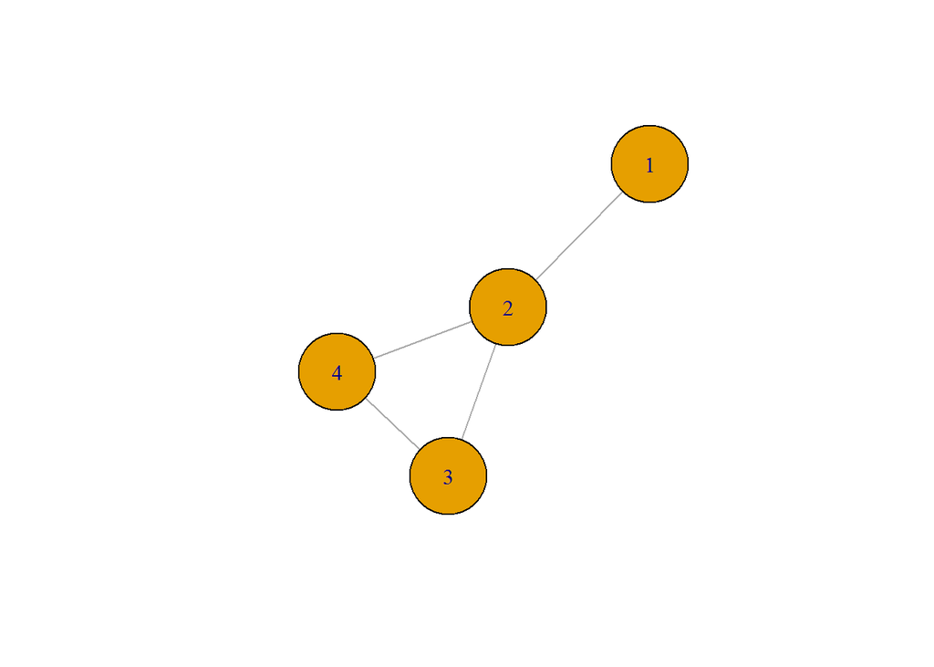

```r
g <- graph.edgelist(edge.list,directed=FALSE)
plot(g,vertex.size=50)
```

### グラフの隣接行列

```r
ad.matrix <- get.adjacency(g)
ad.matrix
```

```
## 4 x 4 sparse Matrix of class "dgCMatrix"
##
## [1,] . 1 . .
## [2,] 1 . 1 1
## [3,] . 1 . 1
## [4,] . 1 1 .
```

1と“.”でできている。 ちょっと見づらいので“.”を0に代える。

```r
A <- as.matrix(ad.matrix)
A
```

```
##      [,1] [,2] [,3] [,4]
## [1,]    0    1    0    0
## [2,]    1    0    1    1
## [3,]    0    1    0    1
## [4,]    0    1    1    0
```

4x4正方行列がグラフgから取り出された。

行列の(i,j)成分が1のとき、頂点i-頂点jの間に辺があり、 そうでないとき、辺がないようにできている。

#### 隣接行列の解釈とべき乗

隣接行列Aの(i,j)成分は、「頂点iから頂点jへと、『１つの辺を辿ってたどり着く通り道の場合の数」を表している、とも言えます。

```r
A2 <- A %*% A
A2
```

```
##      [,1] [,2] [,3] [,4]
## [1,]    1    0    1    1
## [2,]    0    3    1    1
## [3,]    1    1    2    1
## [4,]    1    1    1    2
```

これは$A^2$です。

隣接行列Aの2乗の(i,j)成分は、「頂点iから頂点jへと、『辺をたどること２回でたどり着く通り道の場合の数」を表している、と言えるといいます。

それぞれの成分について、通り道の場合を列挙してみましょう。

$A^3$はどうなるでしょうか？